# Classification Example Using Datasist

## Example use case of datasist in the workflow of a data scientist using a dataset from the [Zindi competitive data science platform](https://zindi.africa/competitions/xente-fraud-detection-challenge)

```python
import pandas as pd
import seaborn as sns
import numpy as np
import matplotlib.pyplot as plt
#Import the Datasist Library
import datasist as ds


#Read in data set
train_data = pd.read_csv('training.csv')
test_data = pd.read_csv('test.csv')
```

Quick summary of a data set using the describe function in the structdata module

```python
ds.structdata.describe(train_data)
```

```
First five data points
```

|  | TransactionId | BatchId | AccountId | SubscriptionId | CustomerId | CurrencyCode | CountryCode | ProviderId | ProductId | ProductCategory | ChannelId | Amount | Value | TransactionStartTime | PricingStrategy | FraudResult |
| --- | --- | --- | --- | --- | --- | --- | --- | --- | --- | --- | --- | --- | --- | --- | --- | --- |
| 0 | TransactionId_76871 | BatchId_36123 | AccountId_3957 | SubscriptionId_887 | CustomerId_4406 | UGX | 256 | ProviderId_6 | ProductId_10 | airtime | ChannelId_3 | 1000.0 | 1000 | 2018-11-15T02:18:49Z | 2 | 0 |
| 1 | TransactionId_73770 | BatchId_15642 | AccountId_4841 | SubscriptionId_3829 | CustomerId_4406 | UGX | 256 | ProviderId_4 | ProductId_6 | financial_services | ChannelId_2 | -20.0 | 20 | 2018-11-15T02:19:08Z | 2 | 0 |
| 2 | TransactionId_26203 | BatchId_53941 | AccountId_4229 | SubscriptionId_222 | CustomerId_4683 | UGX | 256 | ProviderId_6 | ProductId_1 | airtime | ChannelId_3 | 500.0 | 500 | 2018-11-15T02:44:21Z | 2 | 0 |
| 3 | TransactionId_380 | BatchId_102363 | AccountId_648 | SubscriptionId_2185 | CustomerId_988 | UGX | 256 | ProviderId_1 | ProductId_21 | utility_bill | ChannelId_3 | 20000.0 | 21800 | 2018-11-15T03:32:55Z | 2 | 0 |
| 4 | TransactionId_28195 | BatchId_38780 | AccountId_4841 | SubscriptionId_3829 | CustomerId_988 | UGX | 256 | ProviderId_4 | ProductId_6 | financial_services | ChannelId_2 | -644.0 | 644 | 2018-11-15T03:34:21Z | 2 | 0 |

```
Last five data points
```

|  | TransactionId | BatchId | AccountId | SubscriptionId | CustomerId | CurrencyCode | CountryCode | ProviderId | ProductId | ProductCategory | ChannelId | Amount | Value | TransactionStartTime | PricingStrategy | FraudResult |
| --- | --- | --- | --- | --- | --- | --- | --- | --- | --- | --- | --- | --- | --- | --- | --- | --- |
| 95657 | TransactionId_89881 | BatchId_96668 | AccountId_4841 | SubscriptionId_3829 | CustomerId_3078 | UGX | 256 | ProviderId_4 | ProductId_6 | financial_services | ChannelId_2 | -1000.0 | 1000 | 2019-02-13T09:54:09Z | 2 | 0 |
| 95658 | TransactionId_91597 | BatchId_3503 | AccountId_3439 | SubscriptionId_2643 | CustomerId_3874 | UGX | 256 | ProviderId_6 | ProductId_10 | airtime | ChannelId_3 | 1000.0 | 1000 | 2019-02-13T09:54:25Z | 2 | 0 |
| 95659 | TransactionId_82501 | BatchId_118602 | AccountId_4841 | SubscriptionId_3829 | CustomerId_3874 | UGX | 256 | ProviderId_4 | ProductId_6 | financial_services | ChannelId_2 | -20.0 | 20 | 2019-02-13T09:54:35Z | 2 | 0 |
| 95660 | TransactionId_136354 | BatchId_70924 | AccountId_1346 | SubscriptionId_652 | CustomerId_1709 | UGX | 256 | ProviderId_6 | ProductId_19 | tv | ChannelId_3 | 3000.0 | 3000 | 2019-02-13T10:01:10Z | 2 | 0 |
| 95661 | TransactionId_35670 | BatchId_29317 | AccountId_4841 | SubscriptionId_3829 | CustomerId_1709 | UGX | 256 | ProviderId_4 | ProductId_6 | financial_services | ChannelId_2 | -60.0 | 60 | 2019-02-13T10:01:28Z | 2 | 0 |

```
Shape of  data set: (95662, 16)


Size of  data set: 1530592


Data Types
Note: All Non-numerical features are identified as objects in pandas
```

|  | Data Type |
| --- | --- |
| TransactionId | object |
| BatchId | object |
| AccountId | object |
| SubscriptionId | object |
| CustomerId | object |
| CurrencyCode | object |
| CountryCode | int64 |
| ProviderId | object |
| ProductId | object |
| ProductCategory | object |
| ChannelId | object |
| Amount | float64 |
| Value | int64 |
| TransactionStartTime | object |
| PricingStrategy | int64 |
| FraudResult | int64 |

```
Column(s) {'TransactionStartTime'} should be in Datetime format. Use the [to_date] function in datasist.feature_engineering to coonvert to Pandas Datetime format


Numerical Features in Data set
['CountryCode', 'Amount', 'Value', 'PricingStrategy', 'FraudResult']


Statistical Description of Columns
```

|  | CountryCode | Amount | Value | PricingStrategy | FraudResult |
| --- | --- | --- | --- | --- | --- |
| count | 95662.0 | 9.566200e+04 | 9.566200e+04 | 95662.000000 | 95662.000000 |
| mean | 256.0 | 6.717846e+03 | 9.900584e+03 | 2.255974 | 0.002018 |
| std | 0.0 | 1.233068e+05 | 1.231221e+05 | 0.732924 | 0.044872 |
| min | 256.0 | -1.000000e+06 | 2.000000e+00 | 0.000000 | 0.000000 |
| 25% | 256.0 | -5.000000e+01 | 2.750000e+02 | 2.000000 | 0.000000 |
| 50% | 256.0 | 1.000000e+03 | 1.000000e+03 | 2.000000 | 0.000000 |
| 75% | 256.0 | 2.800000e+03 | 5.000000e+03 | 2.000000 | 0.000000 |
| max | 256.0 | 9.880000e+06 | 9.880000e+06 | 4.000000 | 1.000000 |

```
Categorical Features in Data set
```

```
['TransactionId',
 'BatchId',
 'AccountId',
 'SubscriptionId',
 'CustomerId',
 'CurrencyCode',
 'ProviderId',
 'ProductId',
 'ProductCategory',
 'ChannelId',
 'TransactionStartTime']
```

```
Unique class Count of Categorical features
```

|  | Feature | Unique Count |
| --- | --- | --- |
| 0 | TransactionId | 95662 |
| 1 | BatchId | 94809 |
| 2 | AccountId | 3633 |
| 3 | SubscriptionId | 3627 |
| 4 | CustomerId | 3742 |
| 5 | CurrencyCode | 1 |
| 6 | ProviderId | 6 |
| 7 | ProductId | 23 |
| 8 | ProductCategory | 9 |
| 9 | ChannelId | 4 |
| 10 | TransactionStartTime | 94556 |

```
Missing Values in Data
```

|  | features | missing_counts | missing_percent |
| --- | --- | --- | --- |
| 0 | TransactionId | 0 | 0.0 |
| 1 | BatchId | 0 | 0.0 |
| 2 | AccountId | 0 | 0.0 |
| 3 | SubscriptionId | 0 | 0.0 |
| 4 | CustomerId | 0 | 0.0 |
| 5 | CurrencyCode | 0 | 0.0 |
| 6 | CountryCode | 0 | 0.0 |
| 7 | ProviderId | 0 | 0.0 |
| 8 | ProductId | 0 | 0.0 |
| 9 | ProductCategory | 0 | 0.0 |
| 10 | ChannelId | 0 | 0.0 |
| 11 | Amount | 0 | 0.0 |
| 12 | Value | 0 | 0.0 |
| 13 | TransactionStartTime | 0 | 0.0 |
| 14 | PricingStrategy | 0 | 0.0 |
| 15 | FraudResult | 0 | 0.0 |

Remove features that contains only one unique field as these features are redundant

```python
#Drop redundant features
ds.feature_engineering.drop_redundant(data=train_data)
ds.feature_engineering.drop_redundant(data=test_data)
```

```
Dropped ['CurrencyCode', 'CountryCode']
Dropped ['CurrencyCode', 'CountryCode']
```

EXPLORATION OF CATEGORICAL FEATURES

```python
cat_feats = ds.structdata.get_cat_feats(train_data)
```

```python
cat_feats
```

```
['TransactionId',
 'BatchId',
 'AccountId',
 'SubscriptionId',
 'CustomerId',
 'ProviderId',
 'ProductId',
 'ProductCategory',
 'ChannelId',
 'TransactionStartTime']
```

```python
ds.structdata.get_unique_counts(train_data)
```

|  | Feature | Unique Count |
| --- | --- | --- |
| 0 | TransactionId | 95662 |
| 1 | BatchId | 94809 |
| 2 | AccountId | 3633 |
| 3 | SubscriptionId | 3627 |
| 4 | CustomerId | 3742 |
| 5 | ProviderId | 6 |
| 6 | ProductId | 23 |
| 7 | ProductCategory | 9 |
| 8 | ChannelId | 4 |
| 9 | TransactionStartTime | 94556 |

From the unique display output, we notice that the TransactionId and BatchId contains too many classes and thus we can drop them

```python
train_data.drop(['TransactionId', 'BatchId'], axis=1, inplace=True)
test_data.drop(['TransactionId', 'BatchId'], axis=1, inplace=True)
```

VISUALIZATION FOR CATEGORICAL FEATURES

```
Unique Values in AccountId is too large to plot


Unique Values in SubscriptionId is too large to plot


Unique Values in CustomerId is too large to plot


Unique Values in TransactionStartTime is too large to plot
```

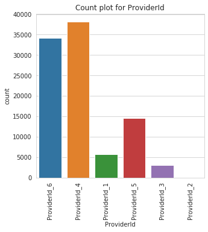

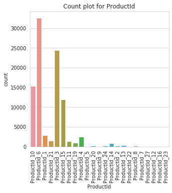

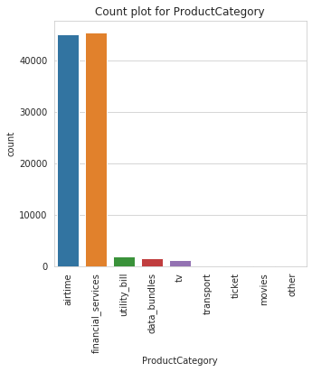

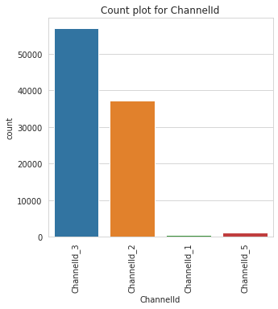

```python
ds.visualizations.countplot(train_data)
```

```python
ds.visualizations.class_count(train_data)
```

```
Unique classes in AccountId too large
Unique classes in SubscriptionId too large
Unique classes in CustomerId too large
Class Count for ProviderId
```

|  | ProviderId |
| --- | --- |
| ProviderId_4 | 38189 |
| ProviderId_6 | 34186 |
| ProviderId_5 | 14542 |
| ProviderId_1 | 5643 |
| ProviderId_3 | 3084 |
| ProviderId_2 | 18 |

```
Unique classes in ProductId too large
Class Count for ProductCategory
```

|  | ProductCategory |
| --- | --- |
| financial_services | 45405 |
| airtime | 45027 |
| utility_bill | 1920 |
| data_bundles | 1613 |
| tv | 1279 |
| ticket | 216 |
| movies | 175 |
| transport | 25 |
| other | 2 |

```
Class Count for ChannelId
```

|  | ChannelId |
| --- | --- |
| ChannelId_3 | 56935 |
| ChannelId_2 | 37141 |
| ChannelId_5 | 1048 |
| ChannelId_1 | 538 |

```
Unique classes in TransactionStartTime too large
```

```python
train_data.columns
```

```
Index(['AccountId', 'SubscriptionId', 'CustomerId', 'ProviderId', 'ProductId',
       'ProductCategory', 'ChannelId', 'Amount', 'Value',
       'TransactionStartTime', 'PricingStrategy', 'FraudResult'],
      dtype='object')
```

[output not shown]

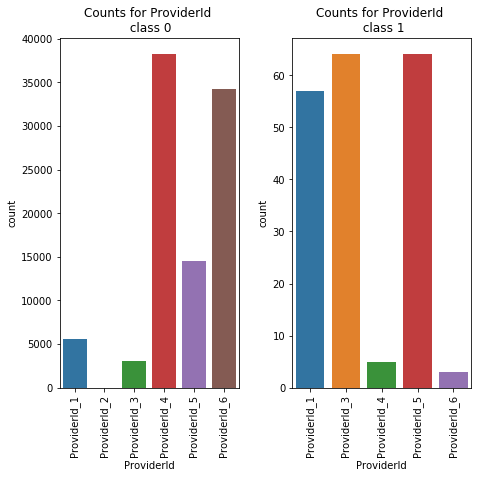

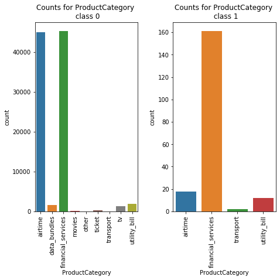

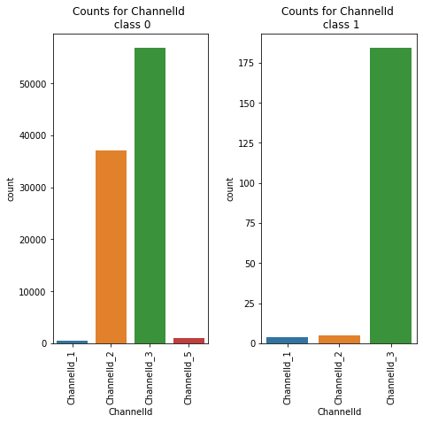

```python
ds.visualizations.catbox(data=train_data, target='FraudResult', fig_size=(7,7))
```

VISUALIZATION OF NUMERICAL FEATURES

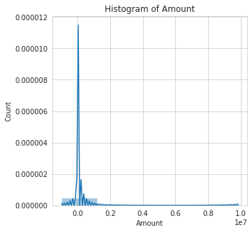

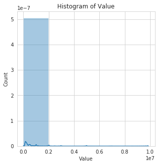

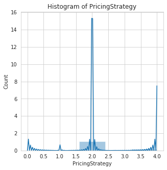

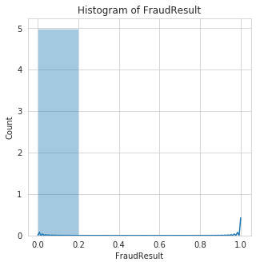

```python
ds.visualizations.histogram(train_data, fig_size=(5,5), bins=5)
```

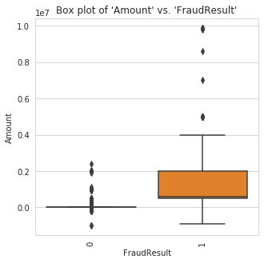

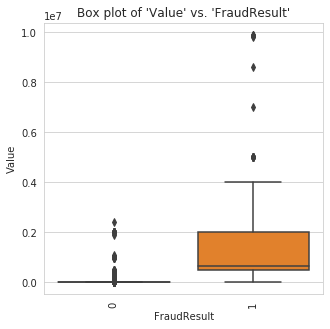

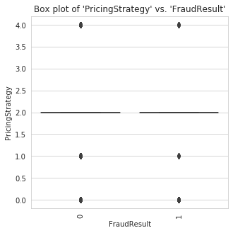

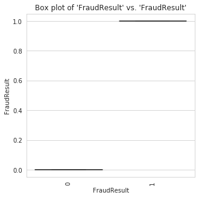

```python
ds.visualizations.boxplot(data=train_data, target='FraudResult', fig_size=(5,5))
```

TIME FEATURES

```python
date_feats = ds.structdata.get_date_cols(train_data)
```

```python
date_feats
```

```
{'TransactionStartTime'}
```

VISUALIZATION OF TIME FEATURES

```python
train_data[date_feats].head()
```

|  | TransactionStartTime |
| --- | --- |
| 0 | 2018-11-15T02:18:49Z |
| 1 | 2018-11-15T02:19:08Z |
| 2 | 2018-11-15T02:44:21Z |
| 3 | 2018-11-15T03:32:55Z |
| 4 | 2018-11-15T03:34:21Z |

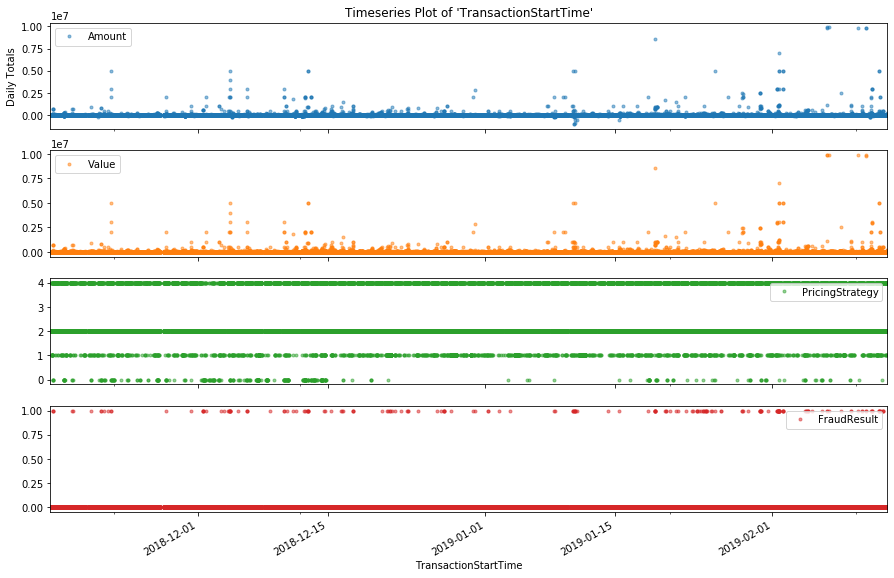

```python
num_feats = ds.structdata.get_num_feats(train_data)

ds.timeseries.num_timeplot(data=train_data,num_cols=num_feats, time_col='TransactionStartTime')
```

The extract_dates function in the timeseries module can extract date information from a datetime column automatically.

```python
train_data = ds.timeseries.extract_dates(data=train_data, date_cols=['TransactionStartTime'])
test_data = ds.timeseries.extract_dates(data=test_data, date_cols=['TransactionStartTime'])
```

```python
train_data.head(2).T
```

|  | 0 | 1 |
| --- | --- | --- |
| AccountId | AccountId_3957 | AccountId_4841 |
| SubscriptionId | SubscriptionId_887 | SubscriptionId_3829 |
| CustomerId | CustomerId_4406 | CustomerId_4406 |
| ProviderId | ProviderId_6 | ProviderId_4 |
| ProductId | ProductId_10 | ProductId_6 |
| ProductCategory | airtime | financial_services |
| ChannelId | ChannelId_3 | ChannelId_2 |
| Amount | 1000 | -20 |
| Value | 1000 | 20 |
| PricingStrategy | 2 | 2 |
| FraudResult | 0 | 0 |
| TransactionStartTime_dow | Thursday | Thursday |
| TransactionStartTime_doy | 319 | 319 |
| TransactionStartTime_dom | 15 | 15 |
| TransactionStartTime_hr | 2 | 2 |
| TransactionStartTime_min | 18 | 19 |
| TransactionStartTime_is_wkd | 0 | 0 |
| TransactionStartTime_yr | 2018 | 2018 |
| TransactionStartTime_qtr | 4 | 4 |
| TransactionStartTime_mth | 11 | 11 |

### MERGE DATA AND ENCODE CATEGORICAL FEATURES

```python
#perform merge
all_data, ntrain, ntest = ds.structdata.join_train_and_test(train_data, test_data)

#Label Encode Large Categorical features
large_cats = ['AccountId', 'SubscriptionId', 'CustomerId', 'ProductId']

from sklearn.preprocessing import LabelEncoder
lb = LabelEncoder()
for cat in large_cats:
    all_data[cat] = lb.fit_transform(all_data[cat])

# One hot encode small categorical features
all_data = pd.get_dummies(all_data, drop_first=True)

#Get traina nd test set back
train = all_data[:ntrain]
test = all_data[ntrain:]

#Get target and drop it
target = train['FraudResult']
train.drop('FraudResult', axis=1, inplace=True)
test.drop('FraudResult', axis=1, inplace=True)

print("Shape of training datasets is {}".format(train.shape))
print("Shape of training target is {}".format(test.shape))
print("Shape of target is {}".format(target.shape))
```

[output not shown]

### MODELING

```python
from sklearn.ensemble import RandomForestClassifier
from sklearn.linear_model import LogisticRegression
from sklearn.metrics import f1_score
from sklearn.model_selection import cross_val_score, train_test_split

X_train, X_test, y_train, y_test = train_test_split(train, target, test_size=0.3, random_state=2)

rf_model = RandomForestClassifier(n_estimators=100,random_state=232)
lg_model = LogisticRegression(max_iter=100, random_state=2, solver='lbfgs')
```

Next, we will train a two classifiers and get detailed report with the datasist classification report function. Can be used to pick best model for a task.

```
Accuracy is  100.0
F1 score is  41.0
Precision is  58.0
Recall is  32.0
confusion Matrix
                 Score positive    Score negative
Actual positive     28629                13
Actual negative        39                18
```

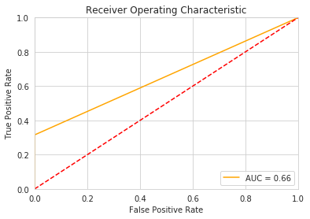

```python
lg_model.fit(X_train, y_train, )
pred = lg_model.predict(X_test)

#Get report from true and predicted values
ds.model.get_classification_report(y_test, pred)
```

```
Accuracy is  100.0
F1 score is  90.0
Precision is  90.0
Recall is  91.0
confusion Matrix
                 Score positive    Score negative
Actual positive     28636                 6
Actual negative         5                52
```

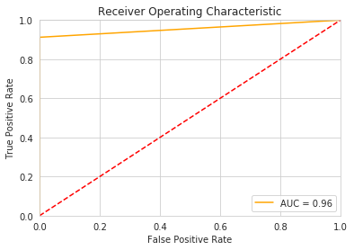

```python
rf_model.fit(X_train, y_train)
pred = rf_model.predict(X_test)

#Get report from true and predicted values
ds.model.get_classification_report(y_test, pred)
```

From the metrics reported, we can see that the RandomForest model does better tahn Logistic Regression. Next we can use a cross validation function to detect overfitting.

```python
ds.model.train_classifier(train_data=train, target=target, model=rf_model, cross_validate=True, cv=3)
```

```
Accuracy is 99.8787
F1_score is 72.1679
Precision is 76.2845
Recall is 79.7035
```

Finally, we can plot the feature importance to see the most important feature

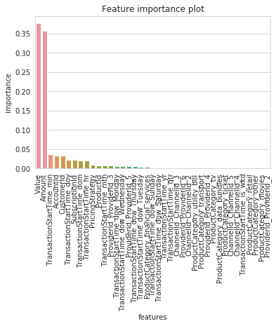

```python
feats = train.columns
ds.model.plot_feature_importance(estimator=rf_model, col_names=feats)
```